# Mobiquity Metereological Dataset

Ruben Sikkes

First loading the dataset.

```r
summary(meteo)
```

[output not shown]

```r
dim(meteo)
```

```
[1] 153   7
```

6 different variables. What do they mean?

Month and day are self explanatory. Wind: mph Temperature: In fahrenheit assumingly so changing to celsius would be °C = (°F - 32) / 1.8 Radiation: w/m2 Ozone.Concentration: in µg/m3

[figure not shown]

```r
library(data.table)
setnames(meteo, "Temperature", "Temperature.F" )
meteo$Temperature.C <- round((meteo$Temperature.F- 32) / 1.8, digits=0)
meteo
```

| X | Month | Day | Wind | Temperature.F | Radiation | Ozone.concentration | Temperature.C |
| --- | --- | --- | --- | --- | --- | --- | --- |
| 1 | 5 | 1 | 7.4 | 67 | 190 | 41 | 19 |
| 2 | 5 | 2 | 8.0 | 72 | 118 | 36 | 22 |
| 3 | 5 | 3 | 12.6 | 74 | 149 | 12 | 23 |
| 4 | 5 | 4 | 11.5 | 62 | 313 | 18 | 17 |
| 5 | 5 | 5 | 14.3 | 56 | NA | NA | 13 |
| 6 | 5 | 6 | 14.9 | 66 | NA | 28 | 19 |
| 7 | 5 | 7 | 8.6 | 65 | 299 | 23 | 18 |
| 8 | 5 | 8 | 13.8 | 59 | 99 | 19 | 15 |
| 9 | 5 | 9 | 20.1 | 61 | 19 | 8 | 16 |
| 10 | 5 | 10 | 8.6 | 69 | 194 | NA | 21 |

[output cut: 143 more lines]

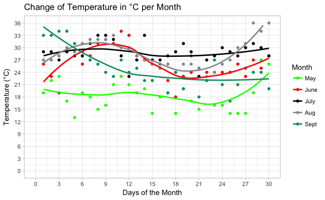

So temperature is highest in July and August. More clear when looking at time as a whole.

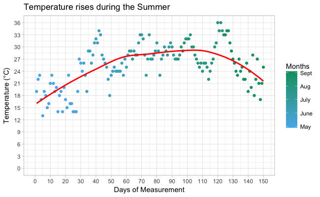

```r
ggplot(meteo, aes(x=X, y=Temperature.C, color=Month))+geom_point()+
  geom_smooth(col= "red",se = FALSE, )+
  theme_light() +
  scale_color_continuous(name="Months",
                         breaks = c(5, 6,7,8,9),
                         labels = c("May", "June", "July","Aug", "Sept"),
                         low = "#56B4E9", high = "#009E73")+
  scale_x_continuous(name = "Days of Measurement",
                     limits = c(0, 150),
                     breaks = seq(0, 150, by = 10))+
  scale_y_continuous(name = "Temperature (°C)",
                     limits = c(0, 36),
                     breaks = seq(0, 36, by = 3))+
  ggtitle("Temperature rises during the Summer")
```

```r
mR2 = summary(lm(Temperature.C ~ log(X), data = meteo))$r.squared
```

Over the summer there is a clear peak.

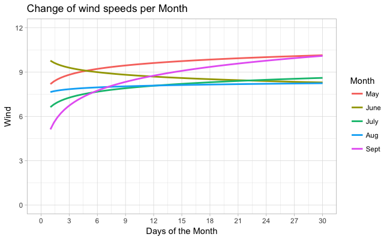

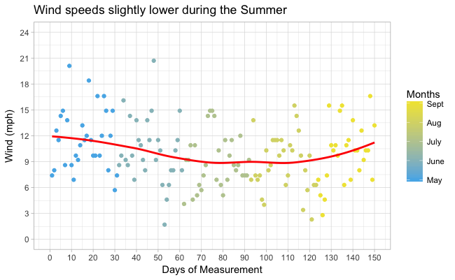

Wind speeds are slightly lower during June-Aug

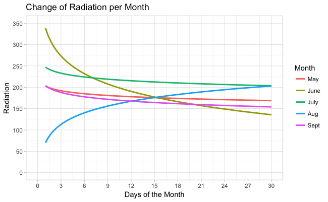

July and august might be a little higher.

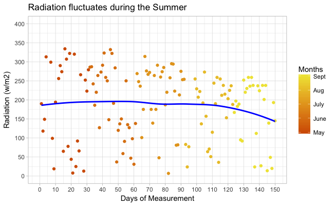

Small peak in the summer.

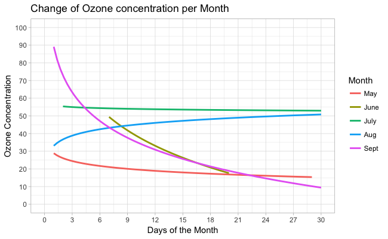

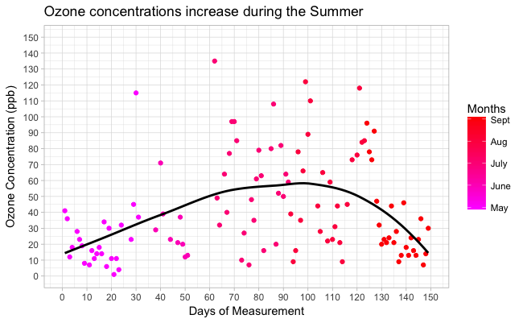

clear peak over the summer.

So during the summer (july and august), Ozone concentrations, temperatures and Radiation levels rise and wind speeds seem to be lower on average. Based on the previous plots Ozone, radiation and temperature should be positively correlated and wind negatively.

Are there any correlations between variables?

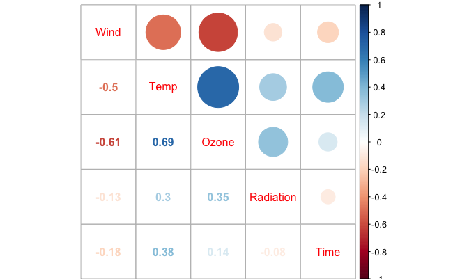

Temperature and wind, Ozone and wind, and Temp and ozone seem to show highest correlations. As predicted wind has a negative correlation while ozone, radiation and temperature are positively correlated.

The positive correlation between ozone concentration and temperature can be seen in the next plot.

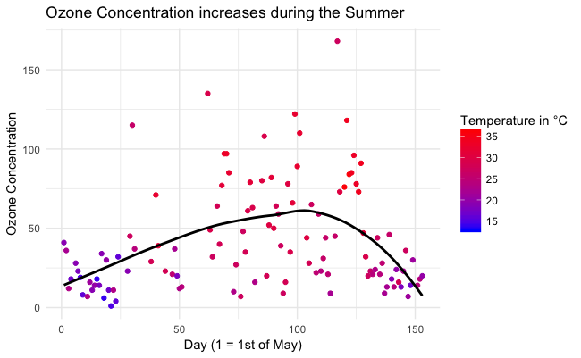

```r
ggplot(meteo, aes(x=X, y= Ozone.concentration, colour= Temperature.C))+ geom_point()+ geom_smooth(col= "black",se = FALSE,)+
               scale_color_continuous(name="Temperature in °C",
                         breaks = c(15, 20, 25,30,35),
                         labels = c("15", "20", "25","30", "35"),
                         low = "blue", high = "red")+
  labs(title="Ozone Concentration increases during the Summer",
       x=  "Day (1 = 1st of May)",
       y= "Ozone Concentration") + theme_minimal()
```

It seems that the Ozone concentration and temperature increase during the summer. Does Ozone cause this increase or is it simply correlation? What does ozone concentration mean?

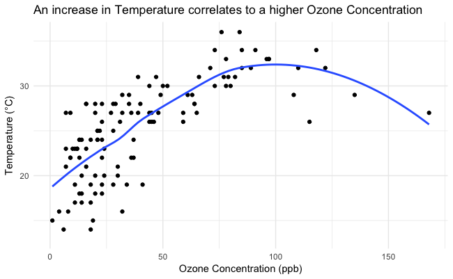

```r
ggplot(meteo, aes(x=Ozone.concentration, y= Temperature.C))+ geom_point()+ geom_smooth(se = FALSE,)+
  labs(title="An increase in Temperature correlates to a higher Ozone Concentration",
       x=  "Ozone Concentration (ppb)",
       y= "Temperature (°C)") + theme_minimal()
```

```r
cor.test(meteo$Ozone.concentration, meteo$Temperature.C, use="complete.obs")
```

```
    Pearson's product-moment correlation

data:  meteo$Ozone.concentration and meteo$Temperature.C
t = 10.227, df = 114, p-value < 2.2e-16
alternative hypothesis: true correlation is not equal to 0
95 percent confidence interval:
 0.5829028 0.7761462
sample estimates:
      cor
0.6917094
```

The correlation between Ozone concentration and temperature becomes quite obvious when looking at this plot. Browsing wikipedia the interaction between temperature and ozone is explained through plants: “Ozone production rises during heat waves, because plants absorb less ozone”. An increase in Temperature therefore seems to cause an increase in Ozone. The other way around ozone is a greenhouse gas so it should also affect temperature.

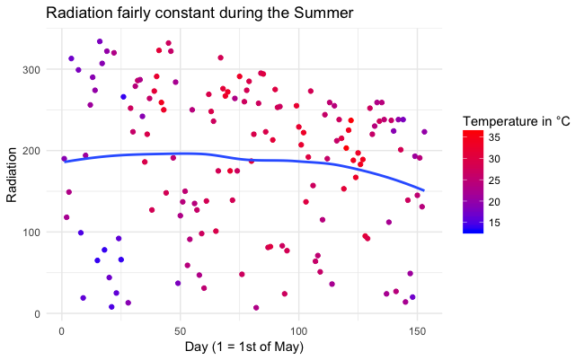

```r
ggplot(meteo, aes(x=X, y= Radiation, colour= Temperature.C))+ geom_point()+
  geom_smooth(se = FALSE,)+
               scale_color_continuous(name="Temperature in °C",
                         breaks = c(15, 20, 25,30,35),
                         labels = c("15", "20", "25","30", "35"),
                         low = "blue", high = "red")+
  labs(title="Radiation fairly constant during the Summer",
       x=  "Day (1 = 1st of May)",
       y= "Radiation") + theme_minimal()
```

```r
cor.test(meteo$Radiation, meteo$Temperature.C, use="complete.obs")
```

```
    Pearson's product-moment correlation

data:  meteo$Radiation and meteo$Temperature.C
t = 3.4652, df = 144, p-value = 0.0006983
alternative hypothesis: true correlation is not equal to 0
95 percent confidence interval:
 0.1204123 0.4209123
sample estimates:
      cor
0.2774339
```

The temperature increases but radiation stays fairly constant.

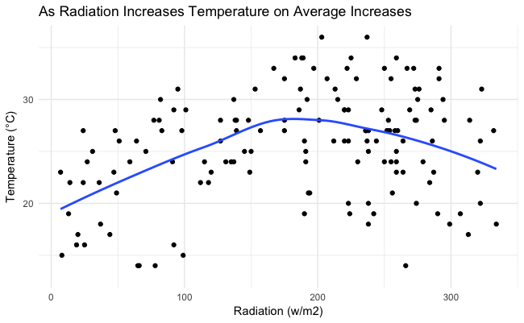

```r
ggplot(meteo, aes(x=Radiation, y= Temperature.C))+ geom_point()+
  geom_smooth(method= "loess",
              se = FALSE,)+
  labs(title="As Radiation Increases Temperature on Average Increases",
       x=  "Radiation (w/m2)",
       y= "Temperature (°C)") + theme_minimal()
```